# Systematic analysis of transcriptional activation from synthetic TP53 binding sites

2023-06-13

[figure not shown]

Website guide: In the “Data Quality Checks” tab plots can be found that describe the pre-processing of the barcode counts and quality assurance. In the “Detailed Reporter Activity Analysis” tab all figures that were generated for the manuscript can be found.

**Introduction:**

It is unclear how TP53 binding site architecture relates to TF activity. To test this systematically, a library was designed in collaboration with the Bussemaker lab. Design features of TP53 reporters like binding site copy number, spacer length, or core promoter choice are reviewed.

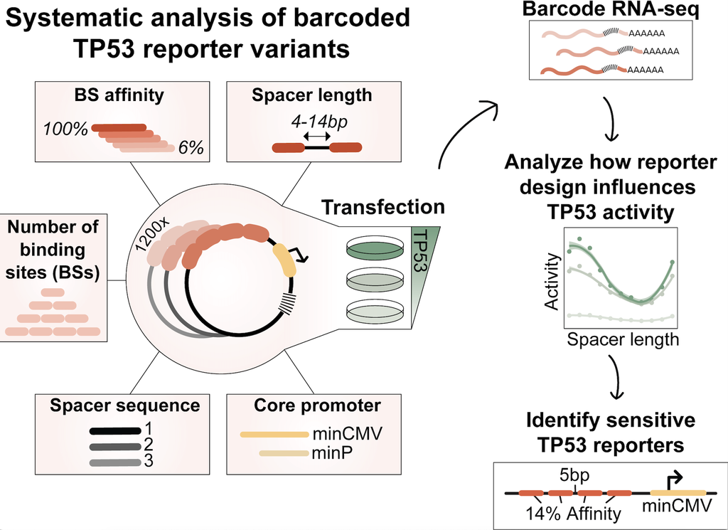

All TF reporters were designed using FIMO. This way, the spacings were designed to be inactive, while the TF binding sites were ensured to be intact.

**Experimental setup:**

- Nucleofection into TP53-proficient MCF7 cells and TP53-KO MCF7 cells
- TP53 Stimulation with Nutlin-3a or vehicle control (DMSO)
- RNA isolation after 24h, followed by barcode-specific reverse transcription and sequencing library prep
- experiments performed in independent triplicates

**Activity quantification:**

- reporter activity = cDNA counts / pDNA counts
- take average across the 5 barcodes
- then take average across the 3 biological replicates
- calculate enrichment per condition tested over background reporter activity (core promoter-only reporters)

**Repository guide:**

- analysis folder: pre-processing of the barcode counts (barcode-preprocessing.Rmd) + analysis of barcode counts, linear modeling, figure generation (cDNA-processing.Rmd)
  - files indicated with #_all# contain data from all three probed cell lines (MCF7, U2OS, A549) whereas the other files only contain the MCF7 data
- library_design folder: contains script that was used to generate the TP53 reporter sequences
- pDNA_insert_seq folder: contains scripts to analyze the full-length sequences of the plasmid pool that was used for transfections
- raw_data_analysis folder: contains the scripts that were used to extract and cluster the raw barcode counts